# Automating Data Exploration with R

## Modeling with Caret

A great modeling library, especially for those new at this, is the [caret](http://topepo.github.io/caret/index.html) package:

> The caret package (short for Classification And Regression Training) is a set of functions that attempt to streamline the process for creating predictive models.

Caret supports a huge number of models and changing your code to handle a new model. Normally this would require a complete re-write of you code, is usually only on parameter change with caret.

Here is how to get the current list of supported models:

```r
#install.packages('dplyr')
library(dplyr)
#install.packages('caret')
library(caret)
names(getModelInfo())
```

```
##   [1] "ada"                 "AdaBag"              "AdaBoost.M1"
##   [4] "adaboost"            "amdai"               "ANFIS"
##   [7] "avNNet"              "awnb"                "awtan"
##  [10] "bag"                 "bagEarth"            "bagEarthGCV"
##  [13] "bagFDA"              "bagFDAGCV"           "bam"
##  [16] "bartMachine"         "bayesglm"            "bdk"
##  [19] "binda"               "blackboost"          "blasso"
##  [22] "blassoAveraged"      "Boruta"              "bridge"
##  [25] "brnn"                "BstLm"               "bstSm"
##  [28] "bstTree"             "C5.0"                "C5.0Cost"
##  [31] "C5.0Rules"           "C5.0Tree"            "cforest"
##  [34] "chaid"               "CSimca"              "ctree"
##  [37] "ctree2"              "cubist"              "dda"
##  [40] "deepboost"           "DENFIS"              "dnn"
##  [43] "dwdLinear"           "dwdPoly"             "dwdRadial"
```

[output cut: 63 more lines]

We’re going to use two models: [gbm (Generalized Boosted Models)](http://www.inside-r.org/packages/cran/gbm/docs/gbm) and [glmnet (Generalized Linear Models)](http://www.inside-r.org/packages/glmnet). Approaching a new data set using different models is one way of getting a handle on your data. **Gbm** uses boosted trees while **glmnet** uses regression.

### GBM (Generalized Boosted Models)

We’ll be using a great healthcare data set on historical readmissions of patients with diabetes - Diabetes 130-US hospitals for years 1999-2008 Data Set. Readmissions is a big deal for hospitals in the US as Medicare/Medicaid will scrutinize those bills and, in some cases, only reimburse a percentage of them. We’ll use code to automate the download and unzipping of the data directly from the UC Irvine Machine Learning Repository.

The data is a bit of a mess so we’re going to have to use our pipeline to sort it out.Let’s get the data:

```r
require(RCurl)
```

```r
binData <- getBinaryURL("https://archive.ics.uci.edu/ml/machine-learning-databases/00296/dataset_diabetes.zip",
                    ssl.verifypeer=FALSE)

conObj <- file("dataset_diabetes.zip", open = "wb")
writeBin(binData, conObj)
# don't forget to close it
close(conObj)

# open diabetes file
files <- unzip("dataset_diabetes.zip")
readLines(files[1], n=5)
```

```
## [1] "encounter_id,patient_nbr,race,gender,age,weight,admission_type_id,discharge_disposition_id,admission_source_id,time_in_hospital,payer_code,medical_specialty,num_lab_procedures,num_procedures,num_medications,number_outpatient,number_emergency,number_inpatient,diag_1,diag_2,diag_3,number_diagn…
## [2] "2278392,8222157,Caucasian,Female,[0-10),?,6,25,1,1,?,Pediatrics-Endocrinology,41,0,1,0,0,0,250.83,?,?,1,None,None,No,No,No,No,No,No,No,No,No,No,No,No,No,No,No,No,No,No,No,No,No,No,No,No,No,NO"
## [3] "149190,55629189,Caucasian,Female,[10-20),?,1,1,7,3,?,?,59,0,18,0,0,0,276,250.01,255,9,None,None,No,No,No,No,No,No,No,No,No,No,No,No,No,No,No,No,No,Up,No,No,No,No,No,Ch,Yes,>30"
## [4] "64410,86047875,AfricanAmerican,Female,[20-30),?,1,1,7,2,?,?,11,5,13,2,0,1,648,250,V27,6,None,None,No,No,No,No,No,No,Steady,No,No,No,No,No,No,No,No,No,No,No,No,No,No,No,No,No,Yes,NO"
## [5] "500364,82442376,Caucasian,Male,[30-40),?,1,1,7,2,?,?,44,1,16,0,0,0,8,250.43,403,7,None,None,No,No,No,No,No,No,No,No,No,No,No,No,No,No,No,No,No,Up,No,No,No,No,No,Ch,Yes,NO"
```

Briefly, we see that we have a header row, comma delimiters, logicals written in text, and NA’s as `?`. We have some work to do. We’ll use the `read_csv` from the `readr` package so we can have it set deal with our NAs.

```r
#install.packages('readr')
library(readr)
diabetes <- data.frame(read_csv(files[1], na = '?'))
dim(diabetes)
```

```
## [1] 101766     50
```

```r
head(diabetes)
```

```
##   encounter_id patient_nbr            race gender     age weight
## 1      2278392     8222157       Caucasian Female  [0-10)   <NA>
## 2       149190    55629189       Caucasian Female [10-20)   <NA>
## 3        64410    86047875 AfricanAmerican Female [20-30)   <NA>
## 4       500364    82442376       Caucasian   Male [30-40)   <NA>
## 5        16680    42519267       Caucasian   Male [40-50)   <NA>
## 6        35754    82637451       Caucasian   Male [50-60)   <NA>
##   admission_type_id discharge_disposition_id admission_source_id
## 1                 6                       25                   1
## 2                 1                        1                   7
## 3                 1                        1                   7
## 4                 1                        1                   7
## 5                 1                        1                   7
## 6                 2                        1                   2
##   time_in_hospital payer_code        medical_specialty num_lab_procedures
```

[output cut: 62 more lines]

Let’s clean it up the data set and drop a few columns to keep things simple:

```r
# drop useless variables
diabetes <- subset(diabetes,select=-c(encounter_id, patient_nbr, examide, citoglipton))

# fix our outcome variable to those readmitted under 30 days
diabetes$readmitted <- ifelse(diabetes$readmitted == "<30",'yes','no')
```

Before we start creating dummy features out of our text data, let’s take a peek at how many unique feature counts we have in our character-based features:

```r
# see what type of classes we have
charcolumns <- names(diabetes[sapply(diabetes, is.character)])
non_numeric_data_dim <- c()
for (colname in charcolumns)
     non_numeric_data_dim <- rbind(non_numeric_data_dim, c(colname, length(unique(diabetes[,colname]))))

non_numeric_data_dim <- data.frame(non_numeric_data_dim) %>%
     mutate(feature_name=as.character(X1), unique_counts=as.numeric(as.character(X2))) %>%
     select(feature_name, unique_counts) %>%
     arrange(desc(unique_counts))

head(non_numeric_data_dim, 10)
```

```
##         feature_name unique_counts
## 1             diag_3           790
## 2             diag_2           749
## 3             diag_1           717
## 4  medical_specialty            73
## 5         payer_code            18
## 6                age            10
## 7             weight            10
## 8               race             6
## 9      max_glu_serum             4
## 10         A1Cresult             4
```

The `diag_X` features are huge. If we binarize all of them, we end up with over 2256 new feature/columns in our data set. To some of you, that may not be a lot, but to most, it is. So we’ll let our `Binarize_Features` function take the 20 most features from each and discard the others. It will do the same with `medical_specialty` as it also has too many unique values.

```r
Binarize_Features <- function(data_set, features_to_ignore=c(), leave_out_one_level=FALSE, max_level_count=20) {
     require(dplyr)
     text_features <- c(names(data_set[sapply(data_set, is.character)]), names(data_set[sapply(data_set, is.factor)]))
     for (feature_name in setdiff(text_features, features_to_ignore)) {
          feature_vector <- as.character(data_set[,feature_name])

          # check that data has more than one level
          if (length(unique(feature_vector)) == 1)
               next

          # We set any non-data to text
          feature_vector[is.na(feature_vector)] <- 'NA'
          feature_vector[is.infinite(feature_vector)] <- 'INF'
          feature_vector[is.nan(feature_vector)] <- 'NAN'

          # only give us the top x most popular categories
          temp_vect <- data.frame(table(feature_vector)) %>% arrange(desc(Freq)) %>% head(max_level_count)
          feature_vector <- ifelse(feature_vector %in% temp_vect$feature_vector, feature_vector, 'Other')

          # loop through each level of a feature and create a new column
          first_level=TRUE
          for (newcol in unique(feature_vector)) {
               if (leave_out_one_level & first_level) {
                    # avoid dummy trap and skip first level
                    first_level=FALSE
                    next
               }

               data_set[,paste0(feature_name,"_",newcol)] <- ifelse(feature_vector==newcol,1,0)
          }
          # remove original feature
          data_set <- data_set[,setdiff(names(data_set),feature_name)]
     }
     return (data_set)
}


diabetes <- Binarize_Features(data_set = diabetes, leave_out_one_level = TRUE,
                              max_level_count = 20, features_to_ignore = 'readmitted')
summary(diabetes)
```

```
##  admission_type_id discharge_disposition_id admission_source_id
##  Min.   :1.000     Min.   : 1.000           Min.   : 1.000
##  1st Qu.:1.000     1st Qu.: 1.000           1st Qu.: 1.000
##  Median :1.000     Median : 1.000           Median : 7.000
##  Mean   :2.024     Mean   : 3.716           Mean   : 5.754
##  3rd Qu.:3.000     3rd Qu.: 4.000           3rd Qu.: 7.000
##  Max.   :8.000     Max.   :28.000           Max.   :25.000
##  time_in_hospital num_lab_procedures num_procedures num_medications
##  Min.   : 1.000   Min.   :  1.0      Min.   :0.00   Min.   : 1.00
##  1st Qu.: 2.000   1st Qu.: 31.0      1st Qu.:0.00   1st Qu.:10.00
##  Median : 4.000   Median : 44.0      Median :1.00   Median :15.00
##  Mean   : 4.396   Mean   : 43.1      Mean   :1.34   Mean   :16.02
##  3rd Qu.: 6.000   3rd Qu.: 57.0      3rd Qu.:2.00   3rd Qu.:20.00
##  Max.   :14.000   Max.   :132.0      Max.   :6.00   Max.   :81.00
##  number_outpatient number_emergency  number_inpatient  number_diagnoses
##  Min.   : 0.0000   Min.   : 0.0000   Min.   : 0.0000   Min.   : 1.000
##  1st Qu.: 0.0000   1st Qu.: 0.0000   1st Qu.: 0.0000   1st Qu.: 6.000
##  Median : 0.0000   Median : 0.0000   Median : 0.0000   Median : 8.000
##  Mean   : 0.3694   Mean   : 0.1978   Mean   : 0.6356   Mean   : 7.423
##  3rd Qu.: 0.0000   3rd Qu.: 0.0000   3rd Qu.: 1.0000   3rd Qu.: 9.000
##  Max.   :42.0000   Max.   :76.0000   Max.   :21.0000   Max.   :16.000
##   readmitted        race_AfricanAmerican    race_NA
##  Length:101766      Min.   :0.0000       Min.   :0.00000
##  Class :character   1st Qu.:0.0000       1st Qu.:0.00000
##  Mode  :character   Median :0.0000       Median :0.00000
##                     Mean   :0.1888       Mean   :0.02234
##                     3rd Qu.:0.0000       3rd Qu.:0.00000
##                     Max.   :1.0000       Max.   :1.00000
##    race_Other       race_Asian       race_Hispanic      gender_Male
##  Min.   :0.0000   Min.   :0.000000   Min.   :0.00000   Min.   :0.0000
##  1st Qu.:0.0000   1st Qu.:0.000000   1st Qu.:0.00000   1st Qu.:0.0000
##  Median :0.0000   Median :0.000000   Median :0.00000   Median :0.0000
##  Mean   :0.0148   Mean   :0.006299   Mean   :0.02002   Mean   :0.4624
##  3rd Qu.:0.0000   3rd Qu.:0.000000   3rd Qu.:0.00000   3rd Qu.:1.0000
##  Max.   :1.0000   Max.   :1.000000   Max.   :1.00000   Max.   :1.0000
##  gender_Unknown/Invalid  age_[10-20)       age_[20-30)
##  Min.   :0.00e+00       Min.   :0.00000   Min.   :0.00000
##  1st Qu.:0.00e+00       1st Qu.:0.00000   1st Qu.:0.00000
##  Median :0.00e+00       Median :0.00000   Median :0.00000
##  Mean   :2.95e-05       Mean   :0.00679   Mean   :0.01628
```

[output cut: 379 more lines]

```
##  Max.   :1.00e+00       Max.   :1.0000000
##  glimepiride.pioglitazone_Steady metformin.rosiglitazone_Steady
##  Min.   :0.0e+00                 Min.   :0.00e+00
##  1st Qu.:0.0e+00                 1st Qu.:0.00e+00
##  Median :0.0e+00                 Median :0.00e+00
##  Mean   :9.8e-06                 Mean   :1.97e-05
##  3rd Qu.:0.0e+00                 3rd Qu.:0.00e+00
##  Max.   :1.0e+00                 Max.   :1.00e+00
##  metformin.pioglitazone_Steady   change_Ch     diabetesMed_Yes
##  Min.   :0.0e+00               Min.   :0.000   Min.   :0.00
##  1st Qu.:0.0e+00               1st Qu.:0.000   1st Qu.:1.00
##  Median :0.0e+00               Median :0.000   Median :1.00
##  Mean   :9.8e-06               Mean   :0.462   Mean   :0.77
##  3rd Qu.:0.0e+00               3rd Qu.:1.000   3rd Qu.:1.00
##  Max.   :1.0e+00               Max.   :1.000   Max.   :1.00
```

Now that we have a fully numeric data set, let’s apply some of our feature-engineering tools and use `nearZeroVar` to remove monotonic features:

```r
Feature_Engineer_Integers <- function(data_set, features_to_ignore=c()) {
     require(infotheo)
     data_set <- data.frame(data_set)

     for (feature_name in setdiff(names(data_set), features_to_ignore)) {
          if (class(data_set[,feature_name])=='numeric' | class(data_set[,feature_name])=='integer') {
               feature_vector <- data_set[,feature_name]

               if (all((feature_vector - round(feature_vector)) == 0)) {
                    # make sure we have more than 2 values excluding NAs
                    if (length(unique(data_set[,feature_name][!is.na(data_set[,feature_name])])) > 2) {
                         print(feature_name)
                         data_set[,paste0(feature_name,'_IsZero')] <- ifelse(data_set[,feature_name]==0,1,0)
                         data_set[,paste0(feature_name,'_IsPositive')] <- ifelse(data_set[,feature_name]>=0,1,0)
                         # separate data into two bins
                         data_discretized <- discretize(data_set[,feature_name], disc='equalfreq', nbins=2)
                         data_set[,paste0(feature_name,'_2Bins')] <- data_discretized$X

                         if (length(unique(data_set[,feature_name][!is.na(data_set[,feature_name])])) > 4) {
                              # try 4 bins
                              data_discretized <- discretize(data_set[,feature_name], disc='equalfreq', nbins=4)
                              data_set[,paste0(feature_name,'_4Bins')] <- data_discretized$X
                         }
                    }
               }
          }
     }
     return (data_set)
}

diabetes <- Feature_Engineer_Integers(data_set=diabetes, features_to_ignore=c('admission_type_id',
                                   'discharge_disposition_id', 'admission_source_id'))
```

```
## [1] "time_in_hospital"
## [1] "num_lab_procedures"
## [1] "num_procedures"
## [1] "num_medications"
## [1] "number_outpatient"
## [1] "number_emergency"
## [1] "number_inpatient"
## [1] "number_diagnoses"
```

```r
nzv <- nearZeroVar(diabetes, saveMetrics = TRUE)
length(rownames(nzv[nzv$nzv==FALSE,]))
```

```
## [1] 66
```

```r
diabetes <- diabetes[,rownames(nzv[nzv$nzv==FALSE,])]
dim(diabetes)
```

```
## [1] 101766     66
```

Now, let’s use `caret` to model this data set using `GBM`. Here we will split the data into two portions: a **training** and a **testing** portion. We’ll use the built-in `createDataPartition` from caret to split the data set in two. By using the same seed you will always get the same split in subsequent runs:

```r
# prep our variables
outcome_name <- 'readmitted'

# cleanup all feature names - replace periods with underscores
predictor_names <- setdiff(names(diabetes), outcome_name)

set.seed(1234)
splitIndex <- createDataPartition(diabetes[,outcome_name], p = .75, list = FALSE, times = 1)
train_data <- diabetes[ splitIndex,]
test_data  <- diabetes[-splitIndex,]
```

**Caret** offers many tuning functions to help you get as much as possible out of your models; the trainControl function allows you to control the resampling of your data. This will split the training data set internally and do it’s own train/test runs to figure out the best settings for your model. In this case, we’re going to cross-validate the data 2 times, therefore training it 2 times on different portions of the data before settling on the best tuning parameters (for **gbm** it is `trees`, `shrinkage`, and `interaction depth`). You can also set these values yourself if you don’t trust the function.

```r
objControl <- trainControl(method='cv', number=2, returnResamp='none',
                           summaryFunction = twoClassSummary, classProbs = TRUE)
```

This is a classification model so we’re requesting that our metrics use [ROC](http://cran.r-project.org/web/packages/caret/vignettes/caret.pdf) instead of the default **RMSE**:

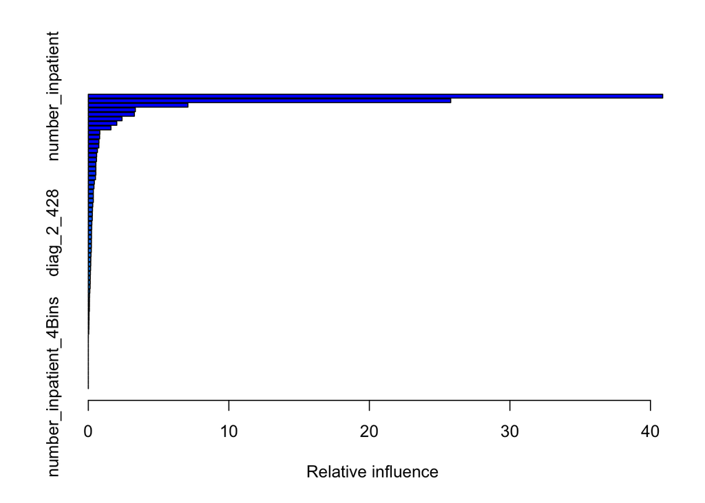

```
##                                                                               var
## number_inpatient                                                 number_inpatient
## discharge_disposition_id                                 discharge_disposition_id
## number_inpatient_IsZero                                   number_inpatient_IsZero
## num_medications                                                   num_medications
## number_emergency                                                 number_emergency
## time_in_hospital                                                 time_in_hospital
## num_lab_procedures                                             num_lab_procedures
## number_diagnoses                                                 number_diagnoses
## diag_1_428                                                             diag_1_428
## diabetesMed_Yes                                                   diabetesMed_Yes
## insulin_Down                                                         insulin_Down
## num_procedures                                                     num_procedures
## number_emergency_IsZero                                   number_emergency_IsZero
## number_diagnoses_2Bins                                     number_diagnoses_2Bins
## admission_type_id                                               admission_type_id
## diag_3_401                                                             diag_3_401
## number_diagnoses_4Bins                                     number_diagnoses_4Bins
## payer_code_MC                                                       payer_code_MC
## change_Ch                                                               change_Ch
## age_.50.60.                                                           age_.50.60.
## time_in_hospital_2Bins                                     time_in_hospital_2Bins
## admission_source_id                                           admission_source_id
## gender_Male                                                           gender_Male
## number_outpatient                                               number_outpatient
## metformin_Steady                                                 metformin_Steady
## medical_specialty_NA                                         medical_specialty_NA
## payer_code_HM                                                       payer_code_HM
## race_AfricanAmerican                                         race_AfricanAmerican
## time_in_hospital_4Bins                                     time_in_hospital_4Bins
## num_medications_2Bins                                       num_medications_2Bins
## diag_2_428                                                             diag_2_428
## medical_specialty_Family.GeneralPractice medical_specialty_Family.GeneralPractice
## diag_3_250                                                             diag_3_250
## medical_specialty_Emergency.Trauma             medical_specialty_Emergency.Trauma
## A1Cresult_.8                                                         A1Cresult_.8
## diag_3_Other                                                         diag_3_Other
## num_procedures_IsZero                                       num_procedures_IsZero
## age_.80.90.                                                           age_.80.90.
## age_.70.80.                                                           age_.70.80.
```

[output cut: 77 more lines]

```
## age_.60.70.                               0.04295513
## age_.40.50.                               0.04024712
## diag_3_276                                0.03051853
## diag_1_414                                0.00000000
## pioglitazone_Steady                       0.00000000
## insulin_Up                                0.00000000
## num_lab_procedures_2Bins                  0.00000000
## num_procedures_2Bins                      0.00000000
## num_procedures_4Bins                      0.00000000
## number_outpatient_2Bins                   0.00000000
## number_outpatient_4Bins                   0.00000000
## number_emergency_2Bins                    0.00000000
## number_emergency_4Bins                    0.00000000
## number_inpatient_2Bins                    0.00000000
## number_inpatient_4Bins                    0.00000000
```

```r
# make outcome variable a factor (required for caret's GBM model)
gbm_caret_model <- train(train_data[,predictor_names], as.factor(train_data[,outcome_name]),
                  method='gbm',
                  trControl=objControl,
                  metric = "ROC",
                  preProc = c("center", "scale"))
summary(gbm_caret_model)
```

We can find out what tuning parameters were most important to the model (notice the last lines about `trees`, `shrinkage` and `interaction depth`:

```r
print(gbm_caret_model)
```

```
## Stochastic Gradient Boosting
##
## 76325 samples
##    65 predictor
##     2 classes: 'no', 'yes'
##
## Pre-processing: centered (65), scaled (65)
## Resampling: Cross-Validated (2 fold)
## Summary of sample sizes: 38162, 38163
## Resampling results across tuning parameters:
##
##   interaction.depth  n.trees  ROC        Sens       Spec
##   1                   50      0.6481373  0.9994986  0.003052360
##   1                  100      0.6554346  0.9990266  0.006339516
##   1                  150      0.6596561  0.9986874  0.008217892
##   2                   50      0.6568785  0.9992036  0.005165532
##   2                  100      0.6659640  0.9986579  0.008570087
##   2                  150      0.6676805  0.9984072  0.010565861
##   3                   50      0.6622102  0.9988792  0.007278704
##   3                  100      0.6683780  0.9983630  0.010565861
##   3                  150      0.6694874  0.9986285  0.011035454
##
## Tuning parameter 'shrinkage' was held constant at a value of 0.1
##
## Tuning parameter 'n.minobsinnode' was held constant at a value of 10
## ROC was used to select the optimal model using  the largest value.
## The final values used for the model were n.trees = 150,
##  interaction.depth = 3, shrinkage = 0.1 and n.minobsinnode = 10.
```

Finally, let’s test out our new model using out test data set. There are two types of evaluation we can do here, `raw` or `prob`. **Raw** gives you a class prediction, in our case `yes` and `nope`, while **prob** gives you the probability on how sure the model is about it’s choice. I always use **prob**, as I like to be in control of the threshold and also like to use [AUC](https://www.kaggle.com/wiki/AreaUnderCurve) score which requires probabilities, not classes. There are situations where having class values can come in handy, such as with multinomial models where you’re predicting more than two values.

We now call the `predict` function and pass it our trained model and our testing data. Let’s start by looking at class predictions and using the **caret** `postResample` function to get an accuracy score:

```r
predictions <- predict(object=gbm_caret_model, test_data[,predictor_names], type='raw')
head(predictions)
```

```
## [1] no no no no no no
## Levels: no yes
```

```r
print(postResample(pred=predictions, obs=as.factor(test_data[,outcome_name])))
```

```
##    Accuracy       Kappa
## 0.888015408 0.009486957
```

The accuracy tells us that our model is correct **89%** of the time - not bad… but keep in mind that most people don’t get readmitted.

```r
prop.table(table(as.factor(diabetes[,outcome_name])))
```

```
##
##        no       yes
## 0.8884008 0.1115992
```

Now let’s look at probabilities:

```r
# probabilites

predictions <- predict(object=gbm_caret_model, test_data[,predictor_names], type='prob')
head(predictions)
```

```
##          no        yes
## 1 0.9472629 0.05273706
## 2 0.9408044 0.05919557
## 3 0.9217157 0.07828429
## 4 0.9120175 0.08798251
## 5 0.8374687 0.16253128
## 6 0.9286577 0.07134228
```

To get the **AUC** score, you need to pass the `yes` column to the `roc` function (each row adds up to 1 but we’re interested in the `yes`, the **readmitted**):

```r
# install.packages('pROC')
library(pROC)
auc <- roc(ifelse(test_data[,outcome_name]=="yes",1,0), predictions[[2]])
print(auc$auc)
```

```
## Area under the curve: 0.6616
```

The **AUC** is telling us that our model has a **0.66 AUC** score (remember that an **AUC** ranges between **0.5** and **1**, where **0.5** is random and **1** is perfect).